# 영화 기생충에 대한 평점과 분석

KIMHEEBUM

2019 7 5

저는 영화 기생충에 대한 네티즌의 평점과 분석을 R을 통하여 해보려합니다.

# 라이브러리 로딩

```r
library(KoNLP)
library(rJava)
library(dplyr)
library(rvest)
library(stringr)
library(xlsx)
```

#웹페이지 크롤링하기 먼저 영화 기생충의 네티즌들의 평점과 리뷰를 분석하기 위하여 데이터를 가져오는 크롤링부터 시작하겠습니다.

```r
trim <- function (x) gsub("^\\s+|\\s+$", "", x)

url_base <- 'https://movie.naver.com'
start_url <- '/movie/bi/mi/point.nhn?code=161967'
url <- paste0(url_base, start_url)
html <- read_html(url)
html %>%
  html_node('iframe.ifr') %>%
  html_attr('src') -> if_url
ifr_url <- paste0(url_base, if_url)
html2 <- read_html(ifr_url)

# 총 데이터 건수로부터 총 페이지수 구하기
html2 %>%
  html_node('div.score_total') %>%
  html_nodes('em') -> ems
pages <- ems[2] %>% html_text()
pages <- gsub(",", "", pages)
total_page <- ceiling(as.numeric(pages)/10)

# 페이지별 url 기본 구하기
html2 %>%
  html_node('div.paging') %>%
  html_node('a') %>%
  html_attr('href') -> tmp
page_url_base <- str_sub(tmp, 1, -2)

# 평점 데이터를 저장할 데이터프레임 초기화
df_points <- data.frame(score=c(), review=c(), writer=c(),
time=c())

for (i in 1:total_page) {
    if (i %% 100 == 0)
    print(i)
  page_url <- paste0(url_base, page_url_base, i)
  html <- read_html(page_url)
  html %>%
    html_node('div.score_result') %>%
    html_nodes('li') -> lis

  score <- c()
  review <- c()
  writer <- c()
  time <- c()
  for (li in lis) {
    score <- c(score, html_node(li, '.star_score') %>%
html_text('em') %>% trim())
    li %>%
      html_node('.score_reple') %>%
      html_text('p') %>%
      trim() -> tmp
    idx <- str_locate(tmp, "\r")
    rev <- str_sub(tmp, 1, idx[1]-1)
    #print(rev)
    review <- c(review, rev)
    tmp <- trim(str_sub(tmp, idx[1], -1))
    idx <- str_locate(tmp, "\r")
    writer <- c(writer, str_sub(tmp, 1, idx[1]-1))
    tmp <- trim(str_sub(tmp, idx[1], -1))
    idx <- str_locate(tmp, "\r")
    time <- c(time, str_sub(tmp, 1, idx[1]-1))
  }
  points <- data.frame(score=score, review=review,
writer=writer, time=time)
  df_points <- rbind.data.frame(df_points, points)
}
```

```
## [1] 100
## [1] 200
## [1] 300
## [1] 400
## [1] 500
## [1] 600
## [1] 700
## [1] 800
## [1] 900
## [1] 1000
## [1] 1100
## [1] 1200
## [1] 1300
## [1] 1400
## [1] 1500
## [1] 1600
## [1] 1700
## [1] 1800
## [1] 1900
## [1] 2000
## [1] 2100
## [1] 2200
## [1] 2300
## [1] 2400
## [1] 2500
## [1] 2600
## [1] 2700
## [1] 2800
## [1] 2900
```

```r
write.csv(df_points, file="D:/cine0.csv",  row.names=F)
```

크롤링 결과를 CSV파일로 저장한 후, 다시 이 파일을 볼러오겠습니다.

```r
library(KoNLP)
library(wordcloud2)
data0 <- read.csv("cine0a.csv", header = T, stringsAsFactors = F)
data1 <- data0$review
data2 <- head(data1,28000)
data2 <- gsub('영화','',data2)
data2 <- gsub('ㅋ','',data2)
data2 <- gsub('ㅎ','',data2)
data2 <- gsub('하게','',data2)
data2 <- gsub('들이','',data2)
data2 <- gsub('하기','',data2)
data2 <- gsub('모두','',data2)
data2 <- gsub('박사','',data2)
data2 <- gsub('찜찜','',data2)
data2 <- gsub('쓰레기','',data2)
data2 <- gsub('였다','',data2)
data2 <- gsub('완전','',data2)
data2 <- gsub('처음','',data2)
data2 <- gsub('봉준호','',data2)
data2 <- gsub('연기','',data2)
data2 <- gsub('냄새','',data2)
data2 <- gsub('관람','',data2)
data2 <- gsub('뭔가','',data2)
data2 <- gsub('대단','',data2)
data2 <- gsub('부분','',data2)
data2 <- gsub('누구','',data2)
data2 <- gsub('근데','',data2)
data2 <- gsub('기생충','',data2)
data2 <- gsub('생각','',data2)
data2 <- gsub('기분','',data2)
data2 <- gsub('재미','',data2)
data2 <- gsub('감독','',data2)
data2 <- gsub('내용','',data2)
data2 <- gsub('표현','',data2)
data2 <- gsub('마음','',data2)
data2 <- gsub('배우','',data2)
data2 <- gsub('가족','',data2)
data2 <- gsub('해서','',data2)
data2 <- gsub('사람','',data2)
data2 <- gsub('장면','',data2)
data2 <- gsub('현실','',data2)
data2 <- gsub('으로','',data2)
data2 <- gsub('이상','',data2)
data2 <- gsub('다들','',data2)
data2 <- gsub('하나','',data2)
data2 <- gsub('해석','',data2)
data2 <- gsub('필요','',data2)
data2 <- gsub('제목','',data2)
data2 <- gsub('우리','',data2)
data2 <- gsub('이해','',data2)
data2 <- gsub('의미','',data2)
data2 <- gsub('수상','',data2)
data2 <- gsub('초반','',data2)
data2 <- gsub('훌륭','',data2)
data2 <- gsub('무엇','',data2)
data2 <- gsub('진짜','',data2)
data2 <- gsub('최고','',data2)
data2 <- gsub('신선','',data2)
data2 <- gsub('ㄷ','',data2)

data3 <- sapply(data2,extractNoun,USE.NAMES=F)

write(unlist(data3), "cine0.txt")
data4 <- readLines("cine0.txt")
data4 <- Filter(function(x) {nchar(x) >= 2}, data4)   # 두 글자 이상만 추출.
data4 <- Filter(function(x) {nchar(x) <= 4}, data4)   # 네 글자 이하

wordcount <- table(data4)
wordcount <- head(sort(wordcount, decreasing=T), 300) #상위 300단어 추출.
wordcount
```

```
## data4
##     불편     충격       15     사회     씁쓸     작품     몰입     가난
##      491      481      470      437      436      408      402      390
##     여운     기대   스토리     불쾌     시간     계획     평점     장르
##      365      352      350      331      319      315      305      290
##   마지막     연출       19     부자     지루   송강호     인생     지하
##      262      250      241      235      234      228      211      211
##   이야기     관객     인간     등급     가슴   재밌게     전개     중간
##      207      206      203      202      200      199      193      191
##     정도     한국     감정     결말     모습     가정     때문     반전
##      190      184      179      170      170      168      164      164
##   오랜만     공감       10 보는내내     기생     잔인   긴장감     추천
##      161      158      157      157      156      156      153      150
##     자체     천재     이유 빈부격차     가지     완벽   청소년     자신
##      149      146      145      144      142      139      137      136
##     후반     대사     예상   누군가   평론가     계단 시나리오     시작
##      132      131      131      129      129      128      126      126
##     답답   메세지   지하철     살인     머리     명작     세상     소름
##      125      124      124      122      120      120      118      118
##     숙주   디테일     순간     대박     공포     문제     부터   스릴러
##      118      115      115      113      108      108      108      108
##     긴장 바퀴벌레     소재   메시지   반지하     실망     계급     기억
##      107      107      104      103      103      102      101      101
##     상황     이거   찝찝한     만큼     예술     박수     역대     설정
##      100       99       98       97       97       96       93       92
##     시계     우울     집중     감사     아래 였습니다     비극     주제
##       92       92       92       90       90       90       88       88
##     사실     웃음     의도     방향     엔딩     자기   적나라     수준
##       86       86       86       82       82       82       82       81
##     오늘     이후     중반     궁금     눈물     서민     수석     조정
##       80       80       80       79       79       79       79       79
##     풍자     해지     간만   무계획     비판     행복     얘기     유쾌
##       79       79       77       77       77       77       76       76
## 자본주의     존재     그것     민망     전달     희망     억지     묘사
##       76       76       75       75       75       75       74       73
##     심장     추억     감동     요소     계층     극장     코믹   개연성
##       73       73       72       72       71       71       71       70
##     상상     인정     기우     세계     친구   코미디     네요     엄마
##       70       70       69       69       69       69       68       68
##     표정     누구   분위기   상징적     시대   한국의     독특     시선
```

[output cut: 22 more lines]

```
##       47       47       47       46       46       46       46       46
##     동안     범죄   봤습니     성공   아줌마   였습니   크레딧     피스
##       45       45       45       45       45       45       45       45
##     고민   무언가     부부     불쌍     불안     ㅠㅠ 감정이입     기괴
##       44       44       44       44       44       44       43       43
##     기준     당신     비유     외국     이것     후회     단순     사랑
##       43       43       43       43       43       43       42       42
##   아버지 기립박수     대비     심오     영상   인디언     참신     칸제
##       42       41       41       41       41       41       41       41
##     확실     감상     단어     대상     유머     자녀     평범     가치
##       41       40       40       40       40       40       40       39
##     그걸     남편     변기   부잣집     비참   스크린     자식     잔혹
##       39       39       39       39       39       39       39       39
##   상받은     인물     걱정     나중
##       38       38       37       37
```

```r
wordcloud2(data=wordcount)
```

[interactive chart not shown]

## 워드클라우드에 대한 평가

이 그림으로 보아, 영화 기생충에 대해서 관람객들은 현실적이고 충격적인 생각을 많이 하였음이 보여집니다. 씁쓸하다, 불쾌하다, 불편하다등 부정적인 단어들이 워드클라우드에 있는걸으로 보아, 이 영화에는 현실의 사회상에 대한 고발적인 내용이 담겨있음을 추측할 수 있으며, 숫자가 15 및 19가 검출되었다는 것은 , 연령제한이 맞지 않음을 의미하는 것 같습니다. 이는 영화 기생충이 몰입감 좋고 재미있는 영화라기 보다는, 씁쓸한 현실적인 사회상을 생각해보게 만드는 영화임을 알 수 있습니다.

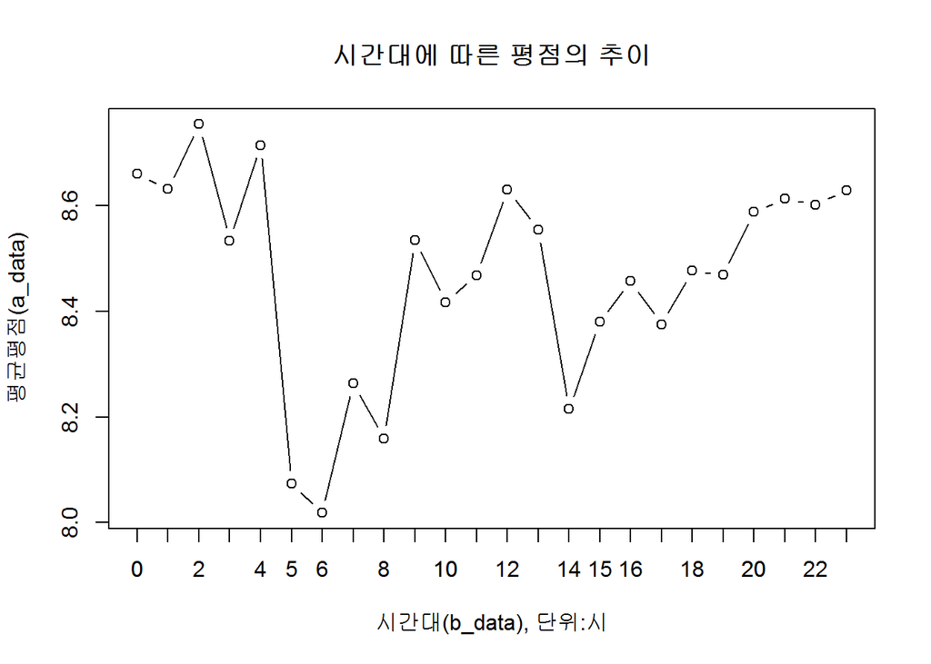

```r
date <- readLines("cine1.txt") #.을 -로 변환하여 불러들임.
date <- as.Date(date, "%Y-%m-%d")  #날짜별 설정
time <- substr(data0$time,12,13) #시간대 설정.

a0 <- data0 %>% filter(substr(data0$time,12,13)=="00")
a1 <- data0 %>% filter(substr(data0$time,12,13)=="01")
a2 <- data0 %>% filter(substr(data0$time,12,13)=="02")
a3 <- data0 %>% filter(substr(data0$time,12,13)=="03")
a4 <- data0 %>% filter(substr(data0$time,12,13)=="04")
a5 <- data0 %>% filter(substr(data0$time,12,13)=="05")
a6 <- data0 %>% filter(substr(data0$time,12,13)=="06")
a7 <- data0 %>% filter(substr(data0$time,12,13)=="07")
a8 <- data0 %>% filter(substr(data0$time,12,13)=="08")
a9 <- data0 %>% filter(substr(data0$time,12,13)=="09")
a10 <-data0 %>% filter(substr(data0$time,12,13)=="10")
a11 <-data0 %>% filter(substr(data0$time,12,13)=="11")
a12 <-data0 %>% filter(substr(data0$time,12,13)=="12")
a13 <-data0 %>% filter(substr(data0$time,12,13)=="13")
a14 <-data0 %>% filter(substr(data0$time,12,13)=="14")
a15 <-data0 %>% filter(substr(data0$time,12,13)=="15")
a16 <-data0 %>% filter(substr(data0$time,12,13)=="16")
a17 <-data0 %>% filter(substr(data0$time,12,13)=="17")
a18 <-data0 %>% filter(substr(data0$time,12,13)=="18")
a19 <-data0 %>% filter(substr(data0$time,12,13)=="19")
a20 <-data0 %>% filter(substr(data0$time,12,13)=="20")
a21 <-data0 %>% filter(substr(data0$time,12,13)=="21")
a22 <-data0 %>% filter(substr(data0$time,12,13)=="22")
a23 <-data0 %>% filter(substr(data0$time,12,13)=="23")

a_data <- c(mean(a0$score),mean(a1$score),mean(a2$score),
            mean(a3$score),mean(a4$score),mean(a5$score),
            mean(a6$score),mean(a7$score),mean(a8$score),
            mean(a9$score),mean(a10$score),mean(a11$score),
            mean(a12$score),mean(a13$score),mean(a14$score),
            mean(a15$score),mean(a16$score),mean(a17$score),
            mean(a18$score),mean(a19$score),mean(a20$score),
            mean(a21$score),mean(a22$score),mean(a23$score))

b_data <- c(0:23)

plot(b_data,a_data, type="b",ann=F) #시간대에 따른 평점의 추이

title(main="시간대에 따른 평점의 추이")
title(xlab="시간대(b_data), 단위:시")
title(ylab="평균평점(a_data)")
axis(1, 0:23)
```

## 시간대에 따른 그래프의 의견:

시간대를 보면, 심야시간이 가장 평점이 높았으며, 아침시간대가 평점이 상대적으로 낮음을 알 수 있습니다. 그러나, 큰 상관관계는 없는 것 같습니다.

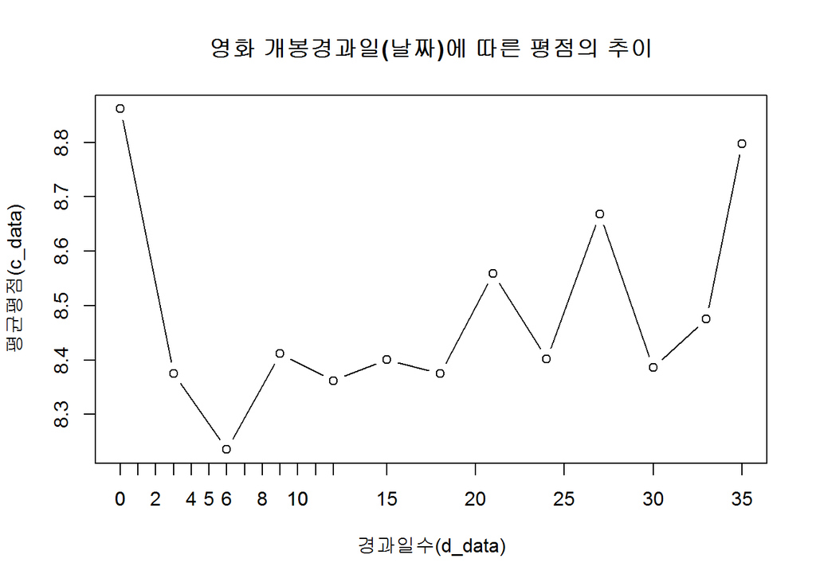

```r
#날짜에 따른 평점의 추이 그래프

c0 <- data0 %>% filter(substr(data0$time,1,10)=="2019.05.30")
c3 <- data0 %>% filter(substr(data0$time,1,10)=="2019.06.02")
c6 <- data0 %>% filter(substr(data0$time,1,10)=="2019.06.05")
c9 <- data0 %>% filter(substr(data0$time,1,10)=="2019.06.08")
c12 <- data0 %>% filter(substr(data0$time,1,10)=="2019.06.11")
c15 <- data0 %>% filter(substr(data0$time,1,10)=="2019.06.14")
c18 <- data0 %>% filter(substr(data0$time,1,10)=="2019.06.17")
c21 <- data0 %>% filter(substr(data0$time,1,10)=="2019.06.20")
c24 <- data0 %>% filter(substr(data0$time,1,10)=="2019.06.23")
c27 <- data0 %>% filter(substr(data0$time,1,10)=="2019.06.26")
c30 <- data0 %>% filter(substr(data0$time,1,10)=="2019.06.29")
c33 <- data0 %>% filter(substr(data0$time,1,10)=="2019.07.02")
c35 <- data0 %>% filter(substr(data0$time,1,10)=="2019.07.04")

c_data <- c(mean(c0$score),
            mean(c3$score),
            mean(c6$score),
            mean(c9$score),
            mean(c12$score),
            mean(c15$score),
            mean(c18$score),
            mean(c21$score),
            mean(c24$score),
            mean(c27$score),
            mean(c30$score),
            mean(c33$score),
            mean(c35$score))

d_data <- c(0,3,6,9,12,15,18,21,24,27,30,33,35)

plot(d_data,c_data,type="b",ann=F)
title(main="영화 개봉경과일(날짜)에 따른 평점의 추이")
title(xlab="경과일수(d_data)")
title(ylab="평균평점(c_data)")
axis(1, at=0:12)
```

## 날짜별로 따른 그래프의 의견:

발매 당일(0)에는 평점이 9점에 가까울 정도로 높았으나, 그후 1주~3주차에서는 평점이 상당히 내려가 있음을 알 수 있습니다. 이것으로 보아, 시청자들은 영화 기생충에 대해서 어느정도 기대감이 있었지만, 기대에 부응하지 못한 점이 있지 않을까 싶습니다. 그후, 3주차부터는 어느정도 평점이 올라갔지만 다시 내려가는 반복적인 형태를 보였습니다. 이는 영화 기생충이 단순한 재미를 위한 영화이기 보다는 사회상을 고발하고, 씁쓸한 현실을 알리는 영화의 특성상, 관람객 모두를 만족시키기에는 어려울 것으로 판단됩니다. 즉, 유의미한 큰 상관관계는 없으며, 평가가 호불호가 갈리는 만큼, 시청에 주의하셔야 할 것 같습니다.